# DATA220G Spring 2017

| Course: | DATA220G - Data Analysis with R |
| --- | --- |
| Semester: | Spring 2017 |
| Instructor: | Bob Rudis |
| Contact Email: | rrudis@ccsnh.edu |
| Day/Time: | TBD |
| Office hours: | By appointment (virtual or in-person) |
| Textbook: | R for Data Science / Advanced R |

# Catalog Description

This course is an applied statistics course that introduces students to key topics in data science, including exploration, statistical data analysis and communicating the results of data analyses. Major topics include advanced R programming language concepts, working as a standalone data analyst and within a team, organizing analysis projects, modeling with univariate, bivariate and multivariate data and basic clustering, classification and time series analysis and forecasting. Prerequisites: C or better in DATA210G (or by department approval) and MATH235G (may be co-requisite).

# Desired Student Competencies

Students will:

- Produce data analysis projects from start to finish individually and as a team.
- Ask and anwer key questions from data sources provided or selected.
- Communicate results clearly through text, code and visulizations.
- Validate findings with basic statistics and machine learning techniques.
- Show proficiency using version control systems.

# Grading/Assessment

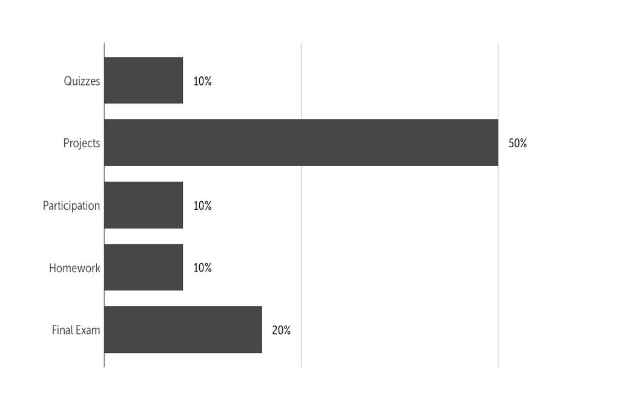

# College Email

I send all class announcements to you at your college email address through Blackboard. You are responsible to check your college email regularly for any and all communication sent to you. Email addresses can be found at the Student Information (SIS) site. Any official correspondence (i.e. notification of absence, withdrawl, etc) not using college email is subject to quarantine and/or removal from the CCSNH email server and will not be answered. If there are technical questions (apart from accessing the RStudio Server setup for the class) that need to be answered, please access the helpdesk. The address is http://greatbay.edu/helpdesk. Personal email addresses cannot be used because SIS and Blackboard are not set up to accommodate them. I check email regularly and will do my best to reply to your email within 24 hours. Again, I only reply to official email from your college address.

# Class Time

Class will be instruction, homework/project review and discussion of new projects. We’re going to try a full remote session for the semester but can switch to in-class if that works out better for folks. We can meet once a week for 3 hours or twice a week for 1.5 hours. Your choice.

# Attendance/Participation Policy

Videos will be made from interative instruction time and available for review. If you miss a session you are responsible for viewing the content. You will not do well if you do not attend or review materials.

# Registrar Procedures Add/Drop Deadlines and Procedures:

Please see the official Planning Calendar (available in all the usual places you’re familiar with) for deadlines with the registrar: deadline to drop with full refund, deadline to drop with a “W”, and deadline to drop with “WP/WF”.

In order to drop this class you must fill out an add/drop form and return this form to the One Stop office for processing. Simply ceasing to attend class or contacting the instructor does not constitute officially dropping the course.

**If you are receiving Financial Aid, you should speak with that office before deciding to withdraw.**

You may withdraw from the course and receive the grade of W, which does not impact your GPA (see Planning Calendar on the last page for this deadline date). No signature from the instructor is required. If past this deadline, the next option is to drop with a “WP/WF”. This option does require an instructor signature and can affect GPA.

# Classroom Decorum/Code of Conduct

In order to create a healthy and productive learning environment there are expectations of all of us. These include:

- Civility in behavior and respect for the rights and opinions of others seeking to learn is highly valued. Please be courteous and respectful at all times. When disagreeing with another’s point of view, no belittling, condemnation or put-downs will be tolerated; keep all comments constructive and helpful in nature.
- It is expected that students will be respectful of GBCC staff and GBCC students. GBCC has a no bullying policy. The Student Code of Conduct can be found in the Student Handbook. The handbook can be found on the College website. Students are responsible for being familiar with the Student Code of Conduct.
- It is expected that we will behave in a manner that is ethically consistent with college policy and in a manner that could not be interpreted as cheating or plagiarism.
- The college defines Plagiarism as, “the intentional or unintentional failure to immediately, accurately, and completely cite and document the source of any language, ideas, summaries, hypotheses, conclusions, interpretations, speculations, graphs, charts, pictures, etc., or other material not entirely your own. This includes failure to cite work of your own that you have used previously.”
- Cheating is defined as using or attempting to use unauthorized materials, information, or study aids in any academic exercise or activity. Failure to meet this expectation could result in a grade of F for the course.
- Consequences for acts of plagairism and/or cheating result in a minimum of 0 for that assignment/quiz/test and maximum of F for the course, depending on the severity of the infringement of the policy.
- I welcome and encourage your input intended to improve the quality of your educational experience.

# Weather Alerts

If school is cancelled for any reason, you should receive an email and/or a phone message from GBCC alerting you. Sign up for “weather alerts” online if you would like a text message. The text messaging service is called “GBCC Alerts” and you will find information to register here: [GBCC Alerts](http://greatbay.edu/campus-life/notifications-announcements)

This should not apply to us.

# Cancellations

If an emergency arises, I will notify Academic Affairs that class has been cancelled and I will send you an email to your college email address via BB.

# Student Support and CAPS

The College is committed to providing support for students with disabilities. Any student with physical, learning, attention, and/or psychological disabilities is encouraged to visit the Center for Academic Planning and Support (CAPS) and make an appointment with the Coordinator of Disability Support Services. More information is available at http://greatbay.edu/student-services/academic-support/disability-services

The Center for Academic Planning and Support (CAPS) has a variety of services to support your academic success at Great Bay Community College. These include:

- Math drop-in assistance from a GBCC math instructor (no appointment needed). Fall Term 2013 drop-in times at posted in CAPS and on CAPS website.
- Free tutoring support on an individual 1-1 basis. For more information about tutoring times, access, availability contact Tutor Coordinator, Carol Despres, at 603-427-7623 or email: cdespres@ccsnh.edu. Schedules are posted at CAPS and updated periodically during each semester at www.greatbay.edu/CAPS
- Study Groups organization and tutor facilitation
- CAPS open computer lab with various course software.
- Individual academic counseling for setting goals, organization, time management and finding strategies to increase learning and performance
- Assistive technology
- ESOL support, nontraditional/gender equity and single parent support
- Career exploration
- Academic workshops - times posted each semester.
- Locations are: 210 at Portsmouth campus and 115 at Rochester campus

Check with CAPS to see all that is available for support for this class.

# Texts

Working in data science means keeping up with advancements in the field (and it is a *broad* field). Here are some key supplemental texts we will be using as part of the course:

- [Advanced R](http://adv-r.had.co.nz/) (Free online)
- [R for Data Science](http://r4ds.had.co.nz/) (Free online)

I’m going to be taking excerpts from [Applied Predictive Modeling](http://appliedpredictivemodeling.com/toc/) and presenting them during the class. You don’t need to buy the book. Having said that, this is a seminal reference that I keep on my desk at all times.

These are some good sites to keep as reference:

- [Beginner’s Guide to R](http://www.computerworld.com/article/2497143/business-intelligence/business-intelligence-beginner-s-guide-to-r-introduction.html)
- [Intro to R](https://www.datacamp.com/courses/free-introduction-to-r)
- [R Cookbook](http://www.cookbook-r.com/)
- [Markdown Reference](https://github.com/adam-p/markdown-here/wiki/Markdown-Cheatsheet)
- [RStudio Resources](https://www.rstudio.com/resources/cheatsheets/)

# Other resources

- YOU WILL NEED a [GitHub](http://github.com/) account. Set one up ASAP.
- I will provide an RStudio Server account if you do not setup R locally
- I’m supposed to store things in Blackboard so that’s going to be the system of record.

# Planning Calendar

See the [official calendar](http://greatbay.edu/academiccalendar?type=list) for the add/drop & official vacation info.

```
Su Mo Tu We Th Fr Sa
 5 16 17 18 19 20 21  1  Jan
22 23 24 25 26 27 28  2
29 30 31  1  2  3  4  3  Feb
 5  6  7  8  9 10 11  4
12 13 14 15 16 17 18  5
19 20 21 22 23 24 25  6
26 27 28  1  2  3  4  7  Mar
 5  6  7  8  9 10 11  8
12 13 14 15 16 17 18  9 ==> SPRING BREAK
19 20 21 22 23 24 25 10
26 27 28 29 30 31  1 11 Apr
 2  3  4  5  6  7  8 12
 9 10 11 12 13 14 15 13
16 17 18 19 20 21 22 14
23 24 25 26 27 28 29 15
30  1  2  3  4  5  6 16 May
 7  8  9 10 11 12 13 17
```

| Date | Topic | What you should have read |
| --- | --- | --- |
| Week 1 | R/RStudio/R Markdown refresher; Elements of the data analysis process; Getting setup with Git | No required pre-reading for this Week 1 |
| Week 2 | Review EDA assignment; Foundations of reproducible research | r4ds 12\|13 |
| Week 3 | Modeling for fun and profit; gnarly data structures | r4ds 22\|23; advr Data Structures\|Subsetting\|Vocabulary |
| Week 4 | NEED TO SEE HOW WEEK 1 & 2 WENT | TBD |
| Week 5 |  |  |
| Week 6 |  |  |
| Week 7 |  |  |
| Week 8 |  |  |
| Week 9 | SPRING BREAK | NO CLASSES |
| Week 10 |  |  |
| Week 11 |  |  |
| Week 12 |  |  |
| Week 13 |  |  |
| Week 14 |  |  |
| Week 15 |  |  |
| Week 16 |  |  |
| Week 17 | My due date for grades | Hopefully you left unscathed! |